### Part II

#### Solution

Tuesday, November 18, 2014

**2.** The TSeLA corporation is opening new retail sales outlets and they want to staff these stores with employees most likely to be successful at selling their ridiculously expensive green products. To meet this goal, TSeLA decides to study the sales staff at existing stores to determine if sex, age, intelligence and extroversion (i.e., a friendly and outgoing personality) predict sales performance of current employees. TSeLA’s logic is that if these character predicts sales performance, then a good strategy for new stores is to hire the sale persons with optimal characteristic for these positions.

To conduct the study, all current retail sales employees at existing stores take psychological tests designed to measure intelligence and extroversion. Also, past sales performance data is checked for each employee. In the end, there are three scores for each sales person:

1. an intelligence score (scale of 50-low intelligence to 150-high intelligence)
2. an extroversion score (scale of 15-low extroversion to 30-high extroversion)
3. sales performance expressed as the average dollar amount sold per week

The data can be found in the tab-delimited file `sales.txt`.

1. Read the data and fit a full first-order additive model with dummy variables (no interaction). Write out the model, can a lack of fit test be conducted to check for model adequacy?  
   **Solution**

```r
raw.text <- "
Person  Gender  Age Intelligence    Extroversion    Sales/Week
1   F   27  89  21  2625
2   F   25  93  24  2700
3   M   29  101 21  3100
4   F   40  122 23  3550
5   M   41  115 27  3175
6   F   35  100 18  2800
7   M   30  98  19  2700
8   M   54  100 16  2475
9   F   42  119 28  3625
10  F   37  109 28  3525
11  M   38  130 20  3225
12  F   36  114 25  3450
13  F   50  91  20  2425
14  F   32  111 26  3025
15  M   33  123 28  3625
16  M   29  115 29  2750
17  M   35  113 25  3150
18  F   25  88  23  2600
19  F   24  102 19  2525
20  M   51  101 16  2650
21  M   33  121 25  3190
22  F   40  112 20  2980
23  F   23  110 20  2735
24  F   37  112 25  3600
25  M   30  121 29  3700
"

sales.df <- read.table(header=TRUE, text=raw.text)

# Solution treats male as baseline
sales.df$Gender <- relevel(x=sales.df$Gender, ref="M")

sales.lm <- lm(formula=Sales.Week ~ Gender + Age + Intelligence + Extroversion, data=sales.df)
summary(sales.lm)
```

```
##
## Call:
## lm(formula = Sales.Week ~ Gender + Age + Intelligence + Extroversion,
##     data = sales.df)
##
## Residuals:
##     Min      1Q  Median      3Q     Max
## -581.36 -117.15    2.69  142.86  417.53
##
## Coefficients:
##              Estimate Std. Error t value Pr(>|t|)
## (Intercept)  -556.317    536.695  -1.037 0.312311
## GenderF       132.869    100.620   1.321 0.201578
## Age             5.585      6.181   0.904 0.376942
## Intelligence   21.377      5.218   4.097 0.000561 ***
## Extroversion   43.701     14.732   2.966 0.007631 **
## ---
## Signif. codes:  0 '***' 0.001 '**' 0.01 '*' 0.05 '.' 0.1 ' ' 1
##
## Residual standard error: 232.3 on 20 degrees of freedom
## Multiple R-squared:  0.7392, Adjusted R-squared:  0.687
## F-statistic: 14.17 on 4 and 20 DF,  p-value: 1.223e-05
```

Model:
$$\widehat{sales} = -556.3 + 132 X_{female} + 5.58 X_{age} + 21.37 X_{intel} + 43.7 X_{extrovert}$$
A Lack of Fit test requires replications at the same level of explanatory variables. The levels of the explanatory variables for each observation is unique. To carry out a lack of fit, we would need to group the age, intelligence, and extroversion score, so that there would be some overlap with the observations.

2. Based on your model from (a), find and interpret a 98% confidence interval for the expected sales per week for a female employee, 30 years of age with an intelligence score of 120 and an extroversion score of 19.  
   **Solution**  
   Scanning through the data, we see that nobody fits profile. We must enter in the data:

```r
predict(object=sales.lm, newdata=data.frame(Gender="F", Age=30, Intelligence=120, Extroversion=19), interval="prediction", level=.98)
```

```
##        fit      lwr      upr
## 1 3139.685 2450.837 3828.532
```

Note: The professor’s solution does not match output. Unclear why.

3. Sketch the plot of residual by age. Is there anything surprising in this plot? Does this finding (if any) change how you would build the model?  
   **Solution**

```
## geom_smooth: method="auto" and size of largest group is <1000, so using loess. Use 'method = x' to change the smoothing method.
```

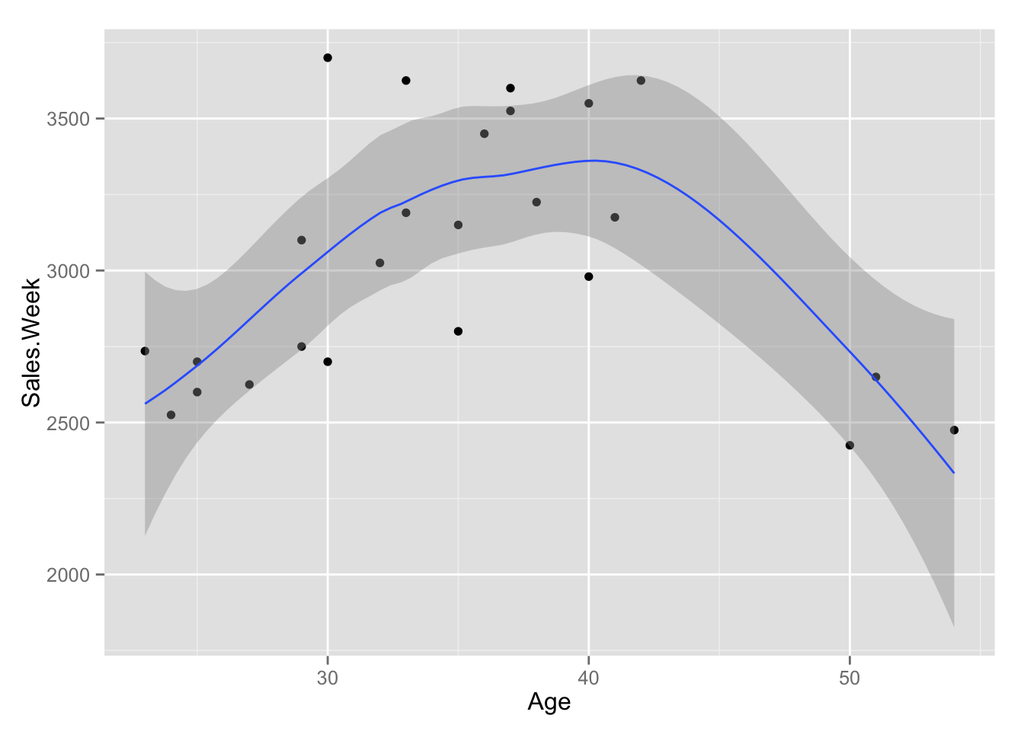

```r
library(ggplot2)
# Solution posts Age vs. Sales
qplot(x=Age, y=Sales.Week, geom=c("point", "smooth"), data=sales.df)
```

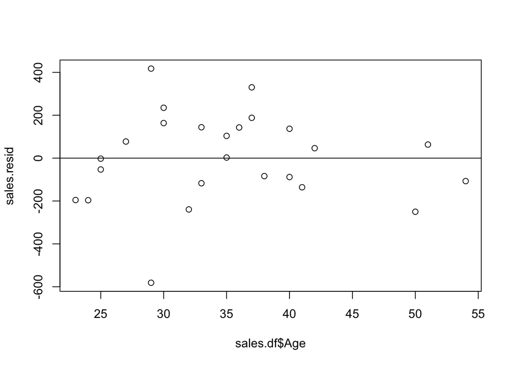

```r
sales.resid <- resid(sales.lm)
plot(x=sales.df$Age, y=sales.resid)
abline(h=0)
```

“Yes, there is a natural curvature relating age to sales, where age seems to reach its premium effect between 30-40.”

4. Write out the adjusted regression equation based on the information you found in (c). In the context of the problem, fully interpret the effect of age and extroversion score.  
   **Solution**

```r
sales.df$AgeSq <- sales.df$Age^2
sales.lm.new <- lm(formula=Sales.Week ~ Gender + Age + AgeSq + Intelligence + Extroversion, data=sales.df)

# Equivalent model to the above
# sales.lm.new <- lm(formula=Sales.Week ~ Gender + Age + I(Age^2) + Intelligence + Extroversion, data=sales.df)
summary(sales.lm.new)
```

```
##
## Call:
## lm(formula = Sales.Week ~ Gender + Age + AgeSq + Intelligence +
##     Extroversion, data = sales.df)
##
## Residuals:
##     Min      1Q  Median      3Q     Max
## -509.97 -127.00   17.07  109.77  332.24
##
## Coefficients:
##                Estimate Std. Error t value Pr(>|t|)
## (Intercept)  -1784.4413   767.4750  -2.325  0.03130 *
## GenderF         94.3345    94.8206   0.995  0.33230
## Age            122.9305    56.2359   2.186  0.04154 *
## AgeSq           -1.5697     0.7484  -2.098  0.04956 *
## Intelligence    15.8021     5.5080   2.869  0.00983 **
## Extroversion    33.8722    14.4035   2.352  0.02963 *
## ---
## Signif. codes:  0 '***' 0.001 '**' 0.01 '*' 0.05 '.' 0.1 ' ' 1
##
## Residual standard error: 214.8 on 19 degrees of freedom
## Multiple R-squared:  0.7882, Adjusted R-squared:  0.7325
## F-statistic: 14.14 on 5 and 19 DF,  p-value: 7.599e-06
```

Model:
$$\widehat{sales} = -1784 + 94.33 X_{female} + 122.93 X_{age} -1.57 X_{age^2} + 15.8 X_{intel} + 33.8 X_{extrovert}$$

5. Perform appropriate tests for normality and constant variance for your final model from (d). Based on these results, comment on the appropriateness of the model.  
   **Solution**  
   Unclear why, but solution relies on a different model:

```r
no.gender.lm <- lm(formula=Sales.Week ~ Age + AgeSq + Intelligence + Extroversion, data=sales.df)
```

Normality:

```r
sales.resid <- resid(object=no.gender.lm)
shapiro.test(x=sales.resid)
```

```
##
##  Shapiro-Wilk normality test
##
## data:  sales.resid
## W = 0.9515, p-value = 0.2703
```

```r
ks.test(x=sales.resid, y='pnorm', mean=0, sd=sd(sales.resid))
```

```
##
##  One-sample Kolmogorov-Smirnov test
##
## data:  sales.resid
## D = 0.1142, p-value = 0.8641
## alternative hypothesis: two-sided
```

```r
library(nortest)
cvm.test(x=sales.resid)
```

```
##
##  Cramer-von Mises normality test
##
## data:  sales.resid
## W = 0.0369, p-value = 0.7244
```

```r
ad.test(x=sales.resid)
```

```
##
##  Anderson-Darling normality test
##
## data:  sales.resid
## A = 0.309, p-value = 0.5341
```

Heteroscedasticity:

```r
library(lmtest)
bptest(no.gender.lm)
```

```
##
##  studentized Breusch-Pagan test
##
## data:  no.gender.lm
## BP = 6.0562, df = 4, p-value = 0.195
```

If you were actually using the model from part (d):

```r
sales.resid <- resid(object=sales.lm.new)
shapiro.test(x=sales.resid)
```

```
##
##  Shapiro-Wilk normality test
##
## data:  sales.resid
## W = 0.9684, p-value = 0.606
```

```r
ks.test(x=sales.resid, y='pnorm', mean=0, sd=sd(sales.resid))
```

```
##
##  One-sample Kolmogorov-Smirnov test
##
## data:  sales.resid
## D = 0.1259, p-value = 0.7778
## alternative hypothesis: two-sided
```

```r
cvm.test(x=sales.resid)
```

```
##
##  Cramer-von Mises normality test
##
## data:  sales.resid
## W = 0.0361, p-value = 0.7397
```

```r
ad.test(x=sales.resid)
```

```
##
##  Anderson-Darling normality test
##
## data:  sales.resid
## A = 0.2551, p-value = 0.6991
```

```r
bptest(sales.lm.new)
```

```
##
##  studentized Breusch-Pagan test
##
## data:  sales.lm.new
## BP = 6.7951, df = 5, p-value = 0.2363
```